# Rice Drought Stress Analysis (GSE115826)

Ayodya Ekanayake (2021/ICT/61)

17 November 2026

# 1. Overview

- **Dataset:** NCBI GEO GSE115826, *Oryza sativa* shoot, day 3, platform GPL6864 (Agilent 4x44K).
- **Samples:** 4 control and 4 drought arrays.
- **Method:** limma (linear model + empirical Bayes), Benjamini-Hochberg adjustment.
- **Comparison:** Drought - Control (positive logFC = higher in drought).
- **Significance rule:** adjusted P < 0.05 and |logFC| >= 1.

# 2. Samples

| GEO_accession | Title | Condition |
| --- | --- | --- |
| GSM3190931 | control day3 shoot replicate 1 | Control |
| GSM3190932 | control day3 shoot replicate 2 | Control |
| GSM3190933 | control day3 shoot replicate 3 | Control |
| GSM3190934 | control day3 shoot replicate 5 | Control |
| GSM3190935 | drought day3 shoot replicate 3 | Drought |
| GSM3190936 | drought day3 shoot replicate 5 | Drought |
| GSM3190937 | drought day3 shoot replicate 6 | Drought |
| GSM3190938 | drought day3 shoot replicate 7 | Drought |

# 3. Data preparation (as done in analysis.R)

- The GEO series matrix values are the Agilent Feature Extraction LogRatio (log10 of Cy5/Cy3).
- Probes with missing or infinite values, and probes with zero variance, were removed.
- The values were multiplied by log2(10) to convert them to the log2 scale.
- Probes on the original series matrix: 45,151. Probes analysed: 43,474.

# 4. Exploratory data analysis

## Per-sample summary

| Sample | Group | Mean | SD | Min | Max |
| --- | --- | --- | --- | --- | --- |
| GSM3190931 | Control | -0.022 | 0.532 | -4.12 | 5.05 |
| GSM3190932 | Control | -0.010 | 0.512 | -4.68 | 3.79 |
| GSM3190933 | Control | -0.015 | 0.476 | -4.58 | 3.52 |
| GSM3190934 | Control | -0.022 | 0.427 | -3.79 | 4.35 |
| GSM3190935 | Drought | 0.040 | 2.164 | -9.77 | 11.63 |
| GSM3190936 | Drought | 0.019 | 2.121 | -10.36 | 12.03 |
| GSM3190937 | Drought | 0.019 | 2.031 | -10.20 | 12.29 |
| GSM3190938 | Drought | 0.023 | 2.017 | -10.40 | 11.83 |

## Figures

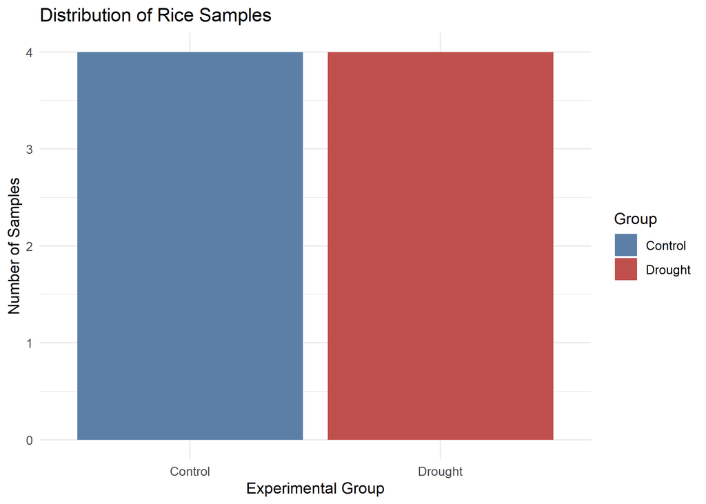

*Figure 1. Samples per group.*

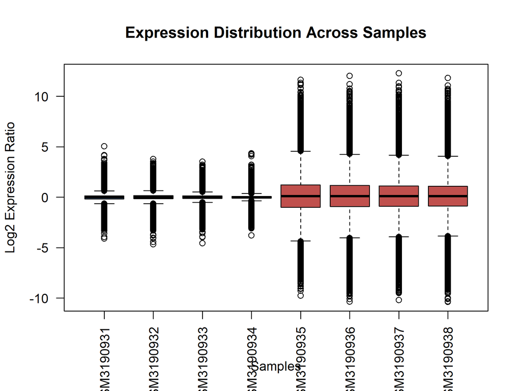

*Figure 2. Expression distribution per sample.*

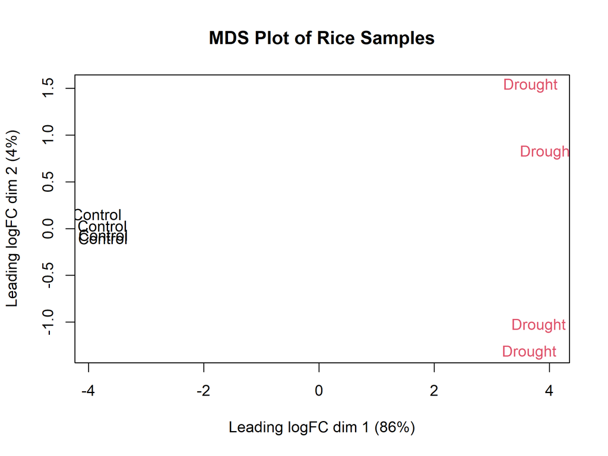

*Figure 3. MDS plot of the eight samples.*

# 5. Differential expression results

| Category | Probes |
| --- | --- |
| Probes analysed | 43,474 |
| Adjusted P < 0.05 | 32,661 |
| Significant (adj. P < 0.05 and \|logFC\| >= 1) | 21,346 |
| Upregulated | 11,550 |
| Downregulated | 9,796 |

## Top 10 most significant probes

| Probe | Locus | logFC | adj.P | Description |
| --- | --- | --- | --- | --- |
| 44582 | Os02g0538700 | -7.71 | 2.14e-09 | Harpin-induced 1 domain containing protein. |
| 41146 | Os09g0127700 | 7.40 | 2.14e-09 | Conserved hypothetical protein. |
| 11202 | Os09g0248100 | -7.46 | 2.14e-09 | Beta-Ig-H3/fasciclin domain containing protein. |
| 35235 | Os07g0257200 | -6.53 | 2.14e-09 | OsNramp1 (Integral membrane protein). |
| 41300 | Os09g0538500 | -8.93 | 2.14e-09 | Male sterility MS5. |
| 14199 | Os01g0136000 | 6.83 | 2.14e-09 | 16.9 kDa class I heat shock protein. |
| 19615 | Os02g0538700 | -8.20 | 2.14e-09 | Harpin-induced 1 domain containing protein. |
| 44259 | Os05g0458500 | -8.15 | 2.14e-09 | Laccase (EC 1.10.3.2). |
| 39577 | Os07g0529000 | 8.68 | 2.72e-09 | Isocitrate lyase (EC 4.1.3.1) (Isocitrase) (Isocitratase) (ICL). |
| 41751 | Os11g0150400 | -6.44 | 2.72e-09 | Conserved hypothetical protein. |

## Top 10 upregulated probes (largest logFC)

| Probe | Locus | logFC | adj.P | Description |
| --- | --- | --- | --- | --- |
| 27499 | Os05g0122700 | 11.83 | 4.20e-09 | Small hydrophobic protein 2. |
| 19960 | Os12g0464400 | 10.75 | 1.07e-08 | Short-chain dehydrogenase/reductase SDR family protein. |
| 18524 | Os03g0826800 | 10.71 | 5.44e-08 | Conserved hypothetical protein. |
| 9841 | Os03g0826800 | 10.56 | 4.11e-07 | Conserved hypothetical protein. |
| 19015 | Os07g0529000 | 10.39 | 3.16e-08 | Isocitrate lyase (EC 4.1.3.1) (Isocitrase) (Isocitratase) (ICL). |
| 21614 | Os11g0700900 | 10.36 | 3.71e-08 | Class III chitinase homologue (OsChib3H-b). |
| 42118 | Os11g0592000 | 10.23 | 7.75e-07 | Barwin. |
| 26265 | Os07g0529000 | 10.20 | 7.89e-08 | Isocitrate lyase (EC 4.1.3.1) (Isocitrase) (Isocitratase) (ICL). |
| 35471 | Os04g0610600 | 10.18 | 4.02e-07 | Cor14b protein precursor. |
| 9091 | Os08g0442900 | 10.11 | 4.20e-09 | Conserved hypothetical protein. |

## Top 10 downregulated probes (smallest logFC)

| Probe | Locus | logFC | adj.P | Description |
| --- | --- | --- | --- | --- |
| 21273 | Os07g0637700 | -9.74 | 5.11e-09 | Plant disease resistance response protein family protein. |
| 12536 | Os06g0678800 | -9.38 | 1.07e-08 | Cupredoxin domain containing protein. |
| 18793 | Os04g0353600 | -9.36 | 1.17e-08 | Male sterility protein family protein. |
| 10461 | Os09g0556800 | -9.31 | 1.07e-08 | Hypothetical protein. |
| 32646 | Os04g0644400 | -9.21 | 1.87e-08 | Proline-rich-like protein. |
| 17095 | Os03g0392600 | -9.16 | 4.84e-08 | Peptidase S10, serine carboxypeptidase family protein. |
| 4710 | Os01g0176500 | -9.11 | 3.38e-07 | Conserved hypothetical protein. |
| 8969 | Os10g0554900 | -9.09 | 2.35e-07 | Protein of unknown function DUF566 family protein. |
| 3971 | Os03g0339400 | -8.99 | 2.72e-09 | Haem peroxidase, plant/fungal/bacterial family protein. |
| 41300 | Os09g0538500 | -8.93 | 2.14e-09 | Male sterility MS5. |

# 6. Volcano plot and heatmap

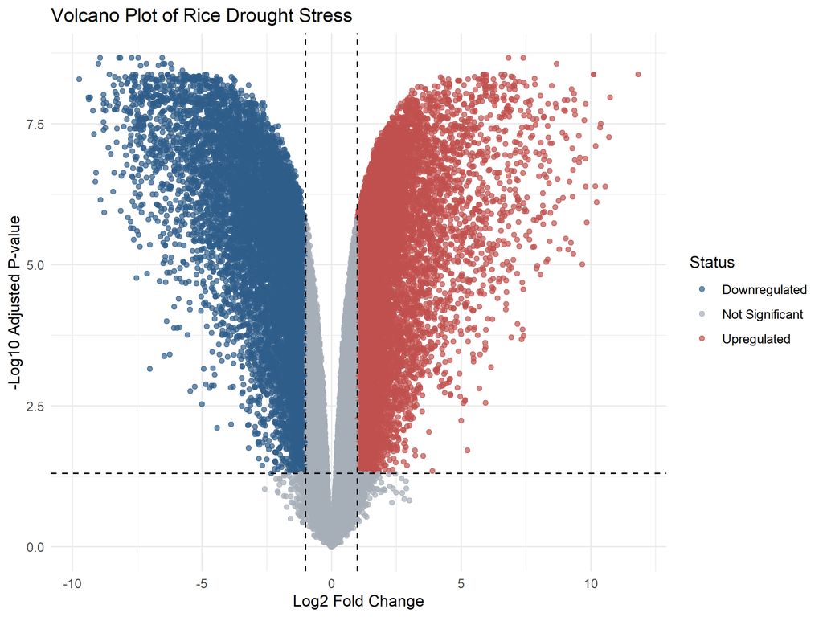

*Figure 4. Volcano plot (Drought vs Control).*

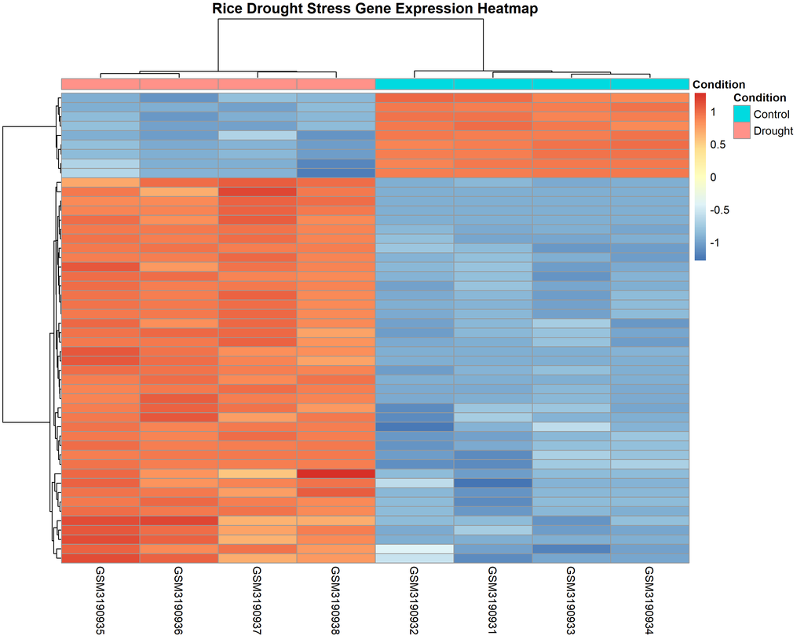

*Figure 5. Heatmap of the 50 most variable probes.*

# 7. Output files

- `results/all_differential_expression.csv`
- `results/significant_probes.csv`
- `results/upregulated_probes.csv`
- `results/downregulated_probes.csv`
- `results/annotated_results.csv`
- `results/clean_expression_matrix.csv`
- `results/sample_metadata.csv`
- `figures/` (5 PNG files)